# Praca domowa 5

Martyna Majchrzak

20 05 2021

## Zbiór danych

Zbiór danych Diabetes zawiera informacje o osobach chorych na cukrzycę. Użyjemy wersji skip z pominiętymi 3 najmniej istotnymi zmiennymi.

1. preg - ile razy dana osoba była w ciąży
2. plas - stężenie glukozy w osoczu po 2h ustnego testu na tolerancję glukozy
3. mass - index masy ciała BMI (waga w kg/(wzrost w m)^2)
4. pedi - obciążenie genetyczne (Diabetes pedigree function)
5. age - wiek (lata)
6. class - zmienna celu o wartościach tested_negative oraz tested_positive

## Rozkłady zmiennych

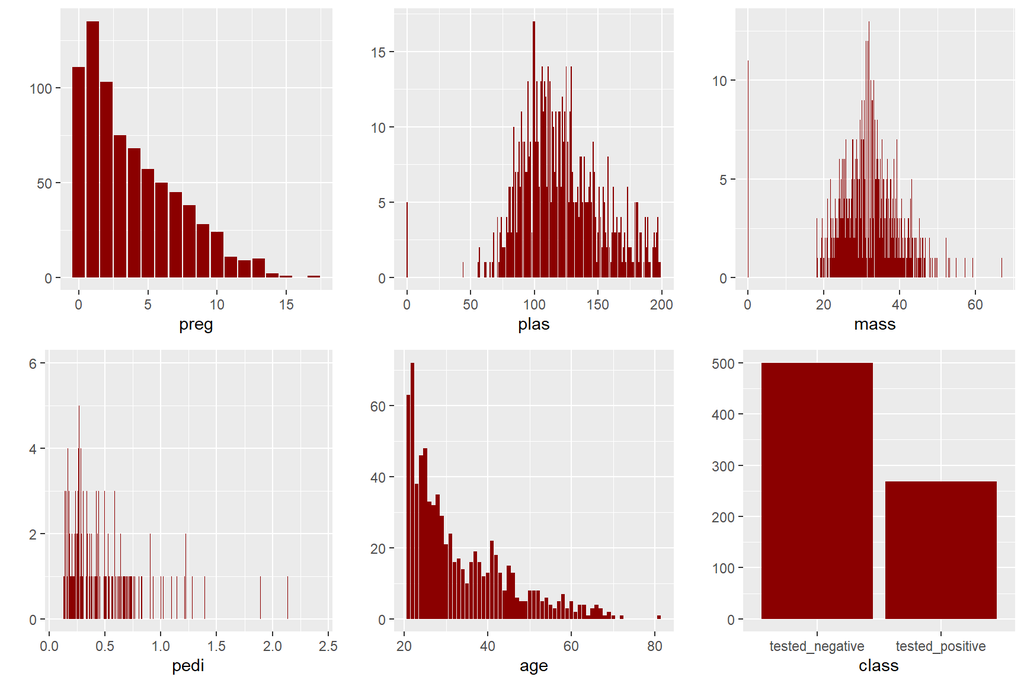

## Model Ranger

[output not shown]

## Model Adaboost

[output not shown]

## Partial Dependence Profiles (PDP)

The partial dependence plot (short PDP or PD plot) shows the marginal effect features have on the predicted outcome of a machine learning model. A partial dependence plot can show whether the relationship between the target and a feature is linear, monotonic or more complex.

### Number of observations

Let’s compare how the Dependence Profile changes depending on the number of observations used for calculation of aggregated profiles

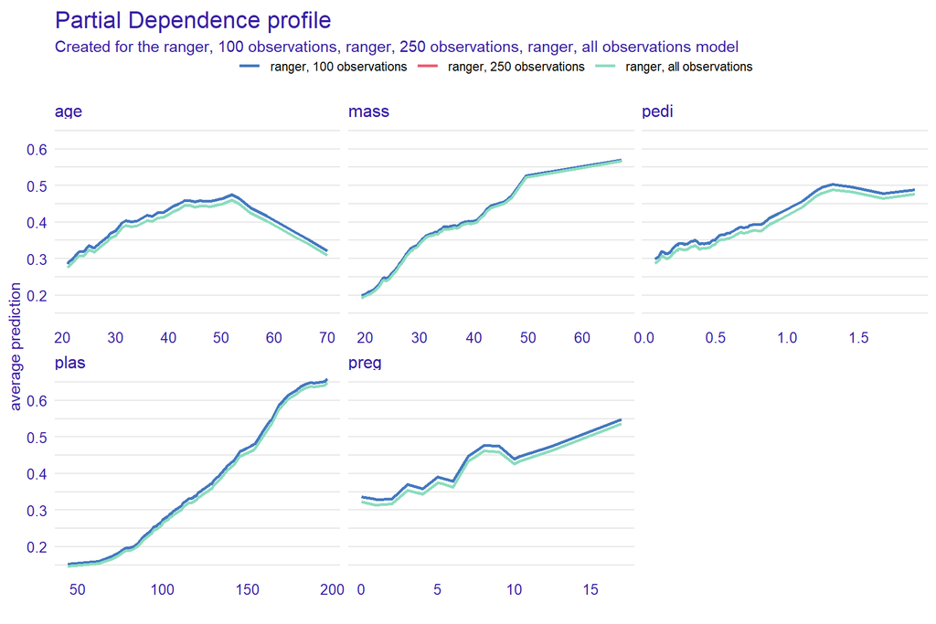

The number of used observations seems to have no influence on the shape of the profile.

### Grid points

Now the comparison of PDP depending on the number of grid points

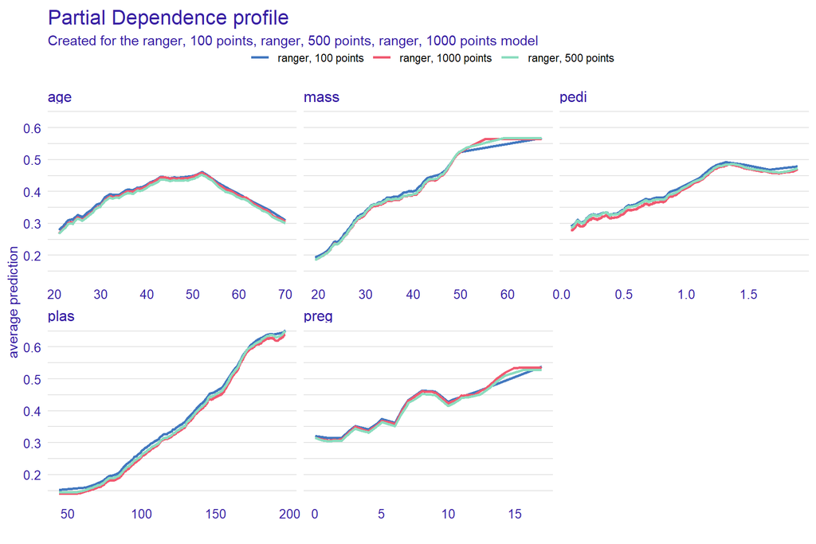

The profiles differ in shape very slightly, the only noticeble difference is in the `mass` for values above 50 (very obese patients) and `preg` variables, for values above 10 (patients, that have in pregnant more than 10 times). More grind points tend to make the plot more detaited.

### Ranger & Ada comparison

Now let’s see the difference between PDP for model Ranger and model Ada, as well as the difference between normal and uniform variable split type.

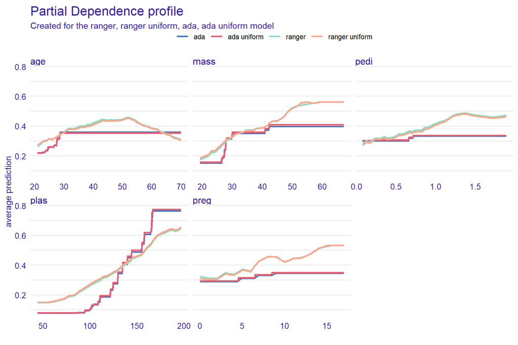

The difference between variable split types is again visible only for big values of `mass` and `preg` variables. The PDP’s for models, however, look very different - the Ranger one is smooth, whereas the Ada one is more angular. This is the effect of the differences in the construction of the models.

## Accumulated Local Dependence (ALE)

Accumulated local Dependence describe how features influence the prediction of a machine learning model on average. ALE plots are a faster and unbiased alternative to PDPs.

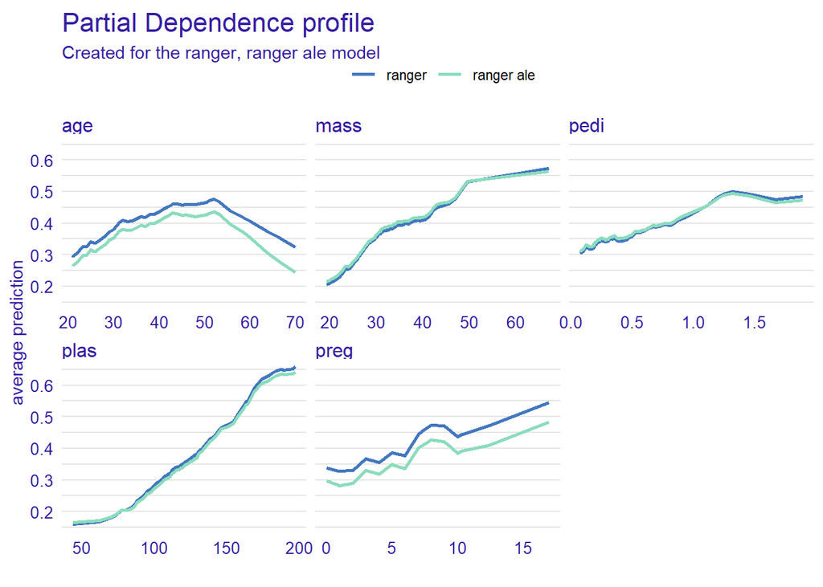

The differences can be seen in the `age` and `preg` - variables. For Accumulated Local Dependence the shape of the profile is roughly the same, but the average predictions tends to be a slightly lower.

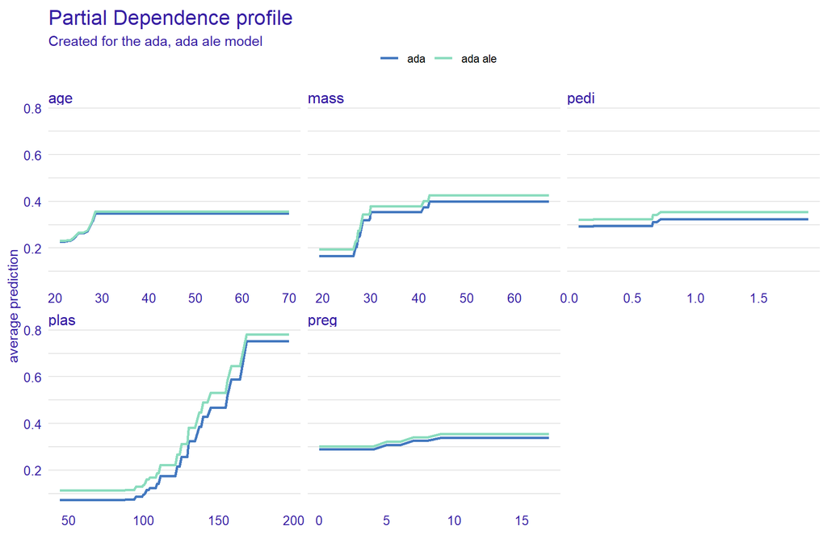

Interestingly, for Ada model the ALE profiles differ form PDP in the rest of variables - `mass`, `pedi` and `plas`. Contary to the ranger model, the average prediction in ALE in higher than the PDP.